# Running window functions

Dawid Kałędkowski

2019-09-30

## About

Package contains standard running functions (aka. windowed, rolling, cumulative) with additional options. `runner` provides extended functionality like date windows, handling missings and varying window size. `runner` brings also rolling streak and rollin which, what extends beyond range of functions already implemented in R packages.

## Installation

Install package from from github or from CRAN.

```r
# devtools::install_github("gogonzo/runner")
install.packages("runner")
```

## Using runner

The main idea of the package is to provide running operations on R vectors. Running functions are these which are applied to all elements up to actual one. For example implemented already in `base` `cumsum`, `cummin` etc. Functions provided in this package works similar but with extended functionality such as handling `NA`, custom window size. The most functions provided in package are based on the same logic

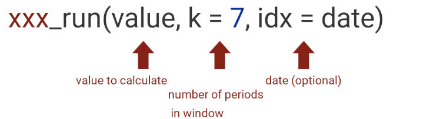

### fixed window size

`k` denotes number of elements in window. For fixed window size `k` should be single value.

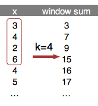

### Varying window size

For varying window size `k` should be of the same length as `x`. Varying window size means that for element `[i]` function will be calculated on window of length `k[i]`.

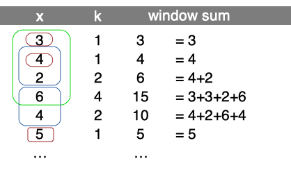

### Windows depending on date

Sometimes data points in dataset are not equally spaced (missing weeekends, holidays, other missings) and thus window size should vary to keep expected time frame. If one specifies `idx` argument, than running functions are applied on windows depending on date. `idx` should be the same length as `x` of class `Date` or `integer`. Including `idx` can be combined with varying window size, than k will denote number of periods in window different for each data point.

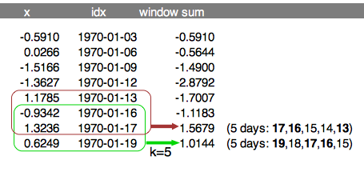

### Other options

- `na_rm = TRUE` handling missing and is equivalent to `na.rm`.

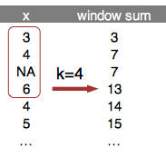

- `na_pad=T` if window size exceeds number of available elements, than first `k-1` elements are filled with `NA`.

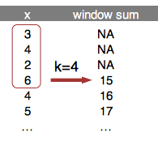

- `which` used with running index, which value (‘first’ or ‘last’)

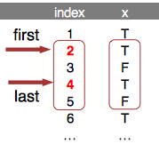

### Running aggregations `(mean|sum|min|max)_run`

Runner provides basic aggregation methods calculated within running windows. Below example showing some functions behavior for different arguments setup. Let’s take a look at 8th element of a vector on which `min_run` is calculated. First setup uses default values, so algorithm is looking for minimum value in all elements before actual (i=8). By default missing values are removed before calculations by argument `na_rm=TRUE`, and also window is not specified. The default is equivalent of `base::cummin` with additional option to ignore `NA` values. In second example within window k=5, the lowest value is -3. In the last example minimum is not available due to existence of `NA`. Graphical example is reproduced below in the code.

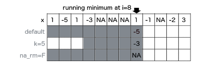

running minimum

```r
library(runner)
library(magrittr)

x <- c(1,-5,1,-3,NA,NA,NA,1,-1,NA,-2,3)
k <- c(4,5,2,5,4,4,2,2,4,4,3,1)
idx <- c(1,3,4,6,7,10,13,16,19,21,23,26)

a0 <- cummin(x)
a1 <- min_run(x, na_rm = TRUE)
a2 <- min_run(x, k=5, na_rm = TRUE)
a3 <- min_run(x, na_rm = FALSE)
a4 <- min_run(x, k=k, na_rm = TRUE, na_pad = TRUE)
a5 <- min_run(x, k=5, idx=idx)


data.frame(idx, x, a0, a1, a2, a3, a4, a5)
```

[output not shown]

### fill_run

Function used to replace `NA` with previous non-NA element. To understand how `fill_run` works, take a look on illustration. Row ‘x’ represents, and another rows represent replaced `NA` by fill_run with different options setup (run_for_first=TRUE and only_within=TRUE respectively). By default, `fill_run` replaces all `NA` if they were preceded by any value. If `NA` appeared in the beginning of the vector then it would not be replaced. But if user specify `run_for_first=TRUE` initial empty values values will be replaced by next non-empty value. Option `only_within=TRUE` means that `NA` values would be replaced if they were surrounded by pair of identical values. No windows provided in this functionality.

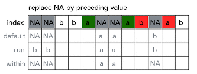

fill run

```r
x <- c(NA, NA, "b","b","a",NA,NA,"a","b",NA,"a","b")
data.frame(x,
           f1 = fill_run(x),
           f2 = fill_run(x,run_for_first = T),
           f3 = fill_run(x, only_within = T))
```

```
#>       x   f1 f2   f3
#> 1  <NA> <NA>  b <NA>
#> 2  <NA> <NA>  b <NA>
#> 3     b    b  b    b
#> 4     b    b  b    b
#> 5     a    a  a    a
#> 6  <NA>    a  a    a
#> 7  <NA>    a  a    a
#> 8     a    a  a    a
#> 9     b    b  b    b
#> 10 <NA>    b  b <NA>
#> 11    a    a  a    a
#> 12    b    b  b    b
```

### Running streak

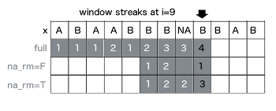

```r
x <- c("A","B","A","A","B","B","B",NA,"B","A","B")
data.frame(
  x,
  s0 = streak_run(x),
  s1 = streak_run(x, na_rm=F, k=3),
  s2 = streak_run(x, k=4) )
```

```
#>       x s0 s1 s2
#> 1     A  1  1  1
#> 2     B  1  1  1
#> 3     A  1  1  1
#> 4     A  2  2  2
#> 5     B  1  1  1
#> 6     B  2  2  2
#> 7     B  3  3  3
#> 8  <NA>  3 NA  3
#> 9     B  4  1  3
#> 10    A  1  1  1
#> 11    B  1  1  1
```

### Running which

To obtain index number of element satisfying some condition in window, one can use running which. Functions from this group returns index while condition is `TRUE` appeared before n-th element of a vector. In below example `whicht_run` function returns index of element containing `TRUE` value. If `na_rm=T` is specified, missing is treated as `FALSE`, and is ignored while searching for `TRUE`. While user set `na_rm=F` like in second example, function returns `NA`, because in following window `TRUE` appears after missing and it’s impossible to be certain which is first (missing is an element of unknown value - could be TRUE or FALSE).

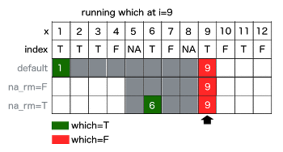

whicht run

```r
x <- c(T,T,T,F,NA,T,F,NA,T,F,T,F)
data.frame(
  x,
  s0 = whicht_run(x, which="first"),
  s1 = whicht_run(x, na_rm=F, k=5, which="first"),
  s2 = whicht_run(x, k=5,"first"))
```

```
#>        x s0 s1 s2
#> 1   TRUE  1  1  1
#> 2   TRUE  1  1  1
#> 3   TRUE  1  1  1
#> 4  FALSE  1  1  1
#> 5     NA  1  1  1
#> 6   TRUE  1  2  2
#> 7  FALSE  1  3  3
#> 8     NA  1 NA  6
#> 9   TRUE  1 NA  6
#> 10 FALSE  1  6  6
#> 11  TRUE  1 NA  9
#> 12 FALSE  1 NA  9
```

### Unique elements in window

User can use `unique_run` create list of unique elements within specified window size.

```r
x2 <- sample( letters[1:3], 6, replace=TRUE)
x2
```

```
#> [1] "b" "a" "a" "b" "b" "c"
```

```r
unique_run( x=x2, k = 3 )
```

```
#> [[1]]
#> [1] "b"
#>
#> [[2]]
#> [1] "b" "a"
#>
#> [[3]]
#> [1] "b" "a"
#>
#> [[4]]
#> [1] "b" "a"
#>
#> [[5]]
#> [1] "b" "a"
#>
#> [[6]]
#> [1] "b" "c"
```

## Apply custom function

### Own runner

One can use own function with function `runner` which will be applied in the same way as other build-in functions.

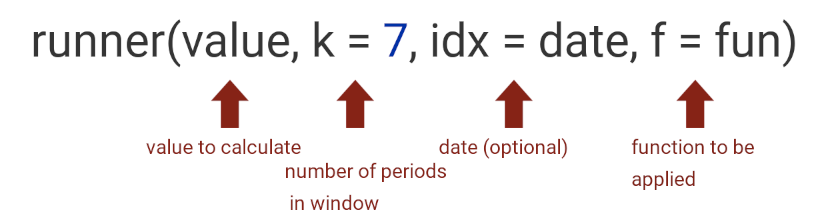

Below example of using `base::mean` inside of the `runner` function.

```r
x <- runif(15)
k <- sample(1:15, 15, replace = TRUE)
idx <- cumsum(sample(c(1,2,3,4), 15, replace=T))

# simple call
simple_mean <- runner(x = x, k = 4, f = mean)

# additional arguments for mean
trimmed_mean <- runner(x = x, k = 4, f = function(x) mean(x, trim = 0.05))

# varying window size
varying_window <- runner(x = x, k = k, f = function(x) mean(x, trim = 0.05))

# date windows
date_windows <- runner(x = x, k = k, idx = idx, f = function(x) mean(x, trim = 0.05))

data.frame(x, k, idx, simple_mean, trimmed_mean, varying_window, date_windows)
```

```
#>             x  k idx simple_mean trimmed_mean varying_window date_windows
#> 1  0.35030550  7   1   0.3503055    0.3503055      0.3503055    0.3503055
#> 2  0.39548334 10   4   0.3728944    0.3728944      0.3728944    0.3728944
#> 3  0.12552336  6   7   0.2904374    0.2904374      0.2904374    0.2605034
#> 4  0.10169480 11   9   0.2432518    0.2432518      0.2432518    0.2432518
#> 5  0.10792572 14  12   0.1826568    0.1826568      0.2161865    0.2161865
#> 6  0.66618558  2  14   0.2503324    0.2503324      0.3870557    0.6661856
#> 7  0.53643660  1  17   0.3530607    0.3530607      0.5364366    0.5364366
#> 8  0.49336883  8  18   0.4509792    0.4509792      0.3471155    0.4509792
#> 9  0.90198479  5  21   0.6494939    0.6494939      0.5411803    0.6439301
#> 10 0.07372355  7  23   0.5013784    0.5013784      0.4116171    0.5013784
#> 11 0.30047822 13  24   0.4423888    0.4423888      0.3684646    0.4400148
#> 12 0.46198571  2  27   0.4345431    0.4345431      0.3812320    0.4619857
#> 13 0.61223545 13  31   0.3621057    0.3621057      0.3944101    0.4700815
#> 14 0.86534728 10  32   0.5600117    0.5600117      0.5019672    0.4627540
#> 15 0.89619544 10  36   0.7089410    0.7089410      0.5807941    0.7089410
```

### Creating windows

Function creates list of windows. Because `runner` provide limited functionality, one can create running-window-list which can be further processed by user to obtain desired statistic (eg. window sum). `x` is a vector to be ‘run on’ and `k` is a length of window. In this example window length is varying as specified by `k`. Provide one value to obtain constant window size.

```r
set.seed(11)
window_run(x = 1:5, k = c(1,2,3,3,2) )
```

```
#> [[1]]
#> [1] 1
#>
#> [[2]]
#> [1] 1 2
#>
#> [[3]]
#> [1] 1 2 3
#>
#> [[4]]
#> [1] 2 3 4
#>
#> [[5]]
#> [1] 4 5
```

Such windows can be used in further calculations, with any R function. Example below shows how to obtain running `sum` in specified, varying window length (specified by `k`).

```r
window_run( x= 1:5, k = c(1,2,3,3,2) ) %>%
  lapply(sum) %>%
  unlist
```

```
#> [1] 1 3 6 9 9
```

One can also specify window based on a date of other numeric index. To do this date should be passed via `idx` argument and k should be integer denoting date-window span.

```r
window_run( x = 1:5, k = 3, idx = c(1,2,5,6,7) )
```

```
#> [[1]]
#> [1] 1
#>
#> [[2]]
#> [1] 1 2
#>
#> [[3]]
#> [1] 3
#>
#> [[4]]
#> [1] 3 4
#>
#> [[5]]
#> [1] 3 4 5
```